# Factores de Severidad en Accidentes de Tránsito en México

Proyecto Final - Módulo 8: Comunicación de resultados

Equipo 6

Betancourt Peralta Diego

Canul Hernández Erick Iván

Gutiérrez Gutiérrez José Omar

Hernández Pérez Maximiliano

Torres Vargas Brenda Poulette

01 de octubre de 2026

# Resumen Ejecutivo

De los 362,926 accidentes de tránsito en zonas urbanas y suburbanas de México registrados por el INEGI en 2025 cuya causa se atribuye al conductor, el 17.8% tuvo al menos una persona herida o fallecida. Para entender qué distingue a estos accidentes de los que solo dejan daños materiales (sin víctimas), ajustamos un modelo de regresión logística con variables del tipo de accidente, características del momento del accidente y el conductor responsable.

El tipo de accidente es, por mucho, el factor que más pesa: los atropellamientos y caídas de pasajeros siempre tienen víctimas, y los choques con ciclista, volcaduras y los choques con motocicleta incrementan en mayor medida el tener víctimas frente a un choque entre automóviles.

Con un umbral de decisión de 0.2, el modelo identifica en el conjunto de prueba el 71.0% de los accidentes con víctimas (recall), con una precisión de 45.8%, una especifidad de 81.6% y un AUC de 0.829.

# Problema y Contexto

De acuerdo con la estadística de **Accidentes de Tránsito Terrestre en Zonas Urbanas y Suburbanas (ATUS)** del INEGI, el 17.8% de los accidentes atribuidos al conductor registrados en 2025 tuvo consecuencias directas sobre al menos una de las personas involucradas, ya sea lesiones (16.8%) o muertes (1.0%). Aunque la mayoría de los accidentes se limita a daños materiales, en esta fracción se concentran los costos humanos más graves. Por eso no basta con saber cuántos accidentes ocurren: hay que distinguir qué condiciones del evento, del entorno y del conductor se asocian con desenlaces más graves, para orientar las acciones de prevención y vigilancia vial y reducir no solo la frecuencia de los accidentes, sino también sus consecuencias.

El objetivo del proyecto es **identificar los factores asociados a que un accidente de tránsito causado por el conductor tenga víctimas**, mediante un modelo de clasificación (regresión logística) con variables del tiempo, del lugar, del contexto del accidente y del conductor presunto responsable, a partir de la edición 2025 de la ATUS. La severidad se define como una variable binaria que distingue entre los accidentes con al menos una persona lesionada o fallecida y aquellos que resultaron únicamente en daños materiales.

# Pregunta de Investigación

> **¿Qué condiciones del evento, del entorno y del conductor presunto responsable se asocian con que un accidente de tránsito en zonas urbanas y suburbanas de México tenga víctimas?**

Consideraremos como accidentes con víctimas aquellos que registraron **al menos una persona herida o fallecida**.

**Preguntas secundarias**:

- ¿Qué tanto pesa el tipo de accidente frente a las características del conductor, del lugar y del momento?
- ¿Hay diferencias entre las regiones del país y se mantienen cuando comparamos el mismo tipo de accidente?
- ¿Qué tan bien identifica el modelo los accidentes con víctimas con un umbral de decisión de 0.2?

**Hipótesis**: Los accidentes que involucran a usuarios más vulnerables (motociclistas y ciclistas), las volcaduras, las zonas suburbanas, la presencia de aliento alcohólico y los conductores jóvenes tienen mayor probabilidad de tener víctimas.

**Variable Objetivo**: `SEVERO` = 1 si el accidente fue fatal o no fatal, 0 si fue de sólo daños.

**Variables explicativas**: tipo de accidente, región, zona, franja horaria, día de la semana, día festivo, y sexo, grupo de edad y presencia de aliento alcohólico del conductor.

**Población de interés**: Accidentes de tránsito en zonas urbanas y suburbanas de México cuya causa fue atribuida al conductor.

**Unidad de análisis**: El accidente.

**Periodo**: Del 01 de enero de 2025 al 31 de diciembre de 2025.

**Alcance geográfico**: Toda la República Mexicana.

# Datos y Procedencia

**Fuente principal:**

- Los datos se obtuvieron del programa de **Accidentes de Tránsito Terrestre en Zonas Urbanas y Suburbanas (ATUS)** del INEGI, disponible en su portal de datos abiertos, en la sección [Archivos para descarga](https://www.inegi.org.mx/programas/accidentes/#datos_abiertos). En ella se encuentran las bases de datos anuales desde 1997 hasta 2025, junto con sus respectivos diccionarios de datos y catálogos, de modo que no fue necesario el uso de APIs.

**Fuentes adicionales:**

- Catálogo de regiones: agrupa las 32 entidades en seis regiones (Noroeste, Noreste, Occidente, Centro, Metropolitana y Sureste). Elaboración propia.
- Para los mapas por entidad usamos los límites estatales de amCharts, una empresa que desarrolla librerías de gráficas y mapas y publica de forma gratuita sus datos geográficos. El archivo proviene del paquete @amcharts/amcharts4-geodata (versión 4.1.32), disponible en [npm](https://www.npmjs.com/package/@amcharts/amcharts4-geodata). Dentro de su carpeta json está mexicoHigh.json, el mapa de México en alta resolución. Es un archivo GeoJSON con 32 polígonos, uno por entidad, cuyos vértices están en longitud y latitud. Cada polígono trae el nombre del estado y su clave ISO 3166-2 (por ejemplo, MX-ZAC para Zacatecas). No modificamos las coordenadas: solo conservamos el nombre y la clave ISO, que renombramos como NOMBRE e ISO, y guardamos el resultado como mexico_estados.geojson.
- Documentación: [Síntesis metodológica de la estadística de accidentes de tránsito terrestres en zonas urbanas y suburbanas 2016](https://www.inegi.org.mx/contenidos/productos/prod_serv/contenidos/espanol/bvinegi/productos/nueva_estruc/702825087999.pdf)

## Alcance

- Delimitamos el análisis a los registros de 2025 y, dentro de ellos, a los accidentes cuya causa presunta se atribuye al conductor (95.6% de los registros totales).
- La unidad de análisis es el Accidente de Tránsito Terrestre en Zonas Urbanas y Suburbanas.
- El alcance geográfico es nacional (las 32 Entidades Federativas).

# Exploración y Preparación

## Estructura general

En principio, observamos que el conjunto de datos original cuenta con **380,391 observaciones y 46 variables**, de las cuales 27 son numéricas (dbl) y 19 categóricas (chr). A continuación, se presenta una breve descripción de dichas variables, agrupadas según su naturaleza:

**Identificadores y cobertura**

- `COBERTURA`: Nivel de cobertura del registro administrativo (Municipal).
- `CVEGEO`: Clave geoestadística de entidad y municipio.
- `CVE_ENT`: Clave de la entidad federativa (01–32).
- `CVE_MUN`: Clave del municipio.
- `ESTATUS`: Situación de las cifras (Cifras Definitivas).

**Variables de tiempo**

- `ANIO`: Año de referencia de la información (2025).
- `MES`: Mes en que ocurrió el accidente.
- `ID_DIA`: Día del mes en que ocurrió el accidente.
- `DIASEMANA`: Día de la semana en que ocurrió el accidente.
- `ID_HORA`: Hora en que ocurrió el accidente (0–23).
- `ID_MINUTO`: Minuto en que ocurrió el accidente.

**Variables de espacio**

- `URBANA`: Ubicación del accidente dentro de zona urbana (en intersección o en no intersección).
- `SUBURBANA`: Ubicación del accidente dentro de zona suburbana (camino rural, carretera estatal u otro camino).

**Variables contextuales del incidente**

- `TIPACCID`: Tipo de accidente según el mecanismo del evento (colisión con vehículo automotor, atropellamiento, volcadura, salida del camino, entre otros).
- `CAUSAACCI`: Causa probable o presunta del accidente (conductor, peatón o pasajero, falla del vehículo, mala condición del camino u otra).
- `CAPAROD`: Capa de rodamiento de la vialidad (pavimentada o no pavimentada).
- `CLASACC`: Clase del accidente según su desenlace (fatal, no fatal o sólo daños).

**Vehículos involucrados**

Cada una de las siguientes variables registra el número de unidades de ese tipo involucradas en el accidente.

- `AUTOMOVIL`: Automóvil.
- `CAMPASAJ`: Camioneta para pasajeros.
- `MICROBUS`: Microbús.
- `PASCAMION`: Camión urbano de pasajeros.
- `OMNIBUS`: Ómnibus.
- `TRANVIA`: Trolebús o tranvía.
- `CAMIONETA`: Camioneta de carga.
- `CAMION`: Camión de carga.
- `TRACTOR`: Tractor con o sin remolque.
- `FERROCARRI`: Ferrocarril.
- `MOTOCICLET`: Motocicleta.
- `BICICLETA`: Bicicleta.
- `OTROVEHIC`: Otro vehículo.

**Sobre el conductor presunto responsable**

- `SEXO`: Sexo del conductor presunto responsable (hombre, mujer o se fugó).
- `ID_EDAD`: Edad del conductor presunto responsable. El valor 0 indica que el conductor se dio a la fuga y el 99 que la edad no fue especificada.
- `ALIENTO`: Presencia de aliento alcohólico (sí, no o se ignora).
- `CINTURON`: Uso de cinturón de seguridad (sí, no o se ignora).

**Víctimas**

Las siguientes variables registran el número de personas muertas o heridas según su rol en el accidente.

- `CONDMUERTO` / `CONDHERIDO`: Conductores muertos y heridos.
- `PASAMUERTO` / `PASAHERIDO`: Pasajeros muertos y heridos.
- `PEATMUERTO` / `PEATHERIDO`: Peatones muertos y heridos.
- `CICLMUERTO` / `CICLHERIDO`: Ciclistas muertos y heridos.
- `OTROMUERTO` / `OTROHERIDO`: Otras personas muertas y heridas.
- `NEMUERTO` / `NEHERIDO`: Personas muertas y heridas cuyo rol no fue especificado.

## Cálidad de los datos

- No hay `NA` explícitos, pero la falta de información viene codificada dentro de las variables: el valor 0 en `ID_EDAD` (el conductor se fugó), el 99 en `ID_EDAD` (edad no especificada) y la categoría “Se ignora” en `ALIENTO` y `CINTURON`. Estos casos los tratamos como faltantes al evaluar cada variable. En vez de eliminarlos o imputarlos, los conservamos como categorías propias: son una parte importante de los registros y que la información no se haya capturado puede estar relacionado con el tipo de accidente.
- “Se fugó” aparece exactamente en los mismo registros en `SEXO` y `ID_EDAD`: si el conductor huye, no se sabe ni su sexo ni edad.
- Hay **748 registros duplicados**.

## Principales Decisiones de Limpieza

- Eliminamos los 748 registros duplicados.
- Solo consideramos los accidentes cuya causa fue el conductor (`CAUSAACCI == "Conductor"`), que son el 95% de la base, ya que las variables sobre el conductor presunto responsable (edad, sexo, aliento alcohólico) solo tienen sentido interpretativo en estos casos.
- Agregamos los nombres de las Entidades Federativas, Municipios y Regiones de la República Mexicana cruzando los datos con los catálogos de entidades federativas del INEGI. Creando así las variables `REGION`, `NOM_ENTIDAD` y `NOM_MUNICIPIO`.
- `MES`, `ID_DIA` e `ID_HORA` se leen como texto; las convertimos a numéricas para construir la variable `FECHA` y con ella crear la variables `FESTIVO``.
- `FESTIVO` vale “Sí” en los días de descanso obligatorio de 2025 según la Ley Federal del Trabajo: 1 de enero, 3 de febrero, 17 de marzo, 1 de mayo, 16 de septiembre, 17 de noviembre y 25 de diciembre.
- Agrupamos la hora del accidente en cuatro categorías en la variable `FRANJA_HORARIA`: Madrugada (0 a 5 h), Mañana (6 a 11 h), Tarde (12 a 17 h) y Noche (18 a 23 h).
- Codificamos la **variable objetivo** `SEVERO`: 1 = Fatal o No fatal (el accidente tuvo víctimas), 0 = Solo daños.
- Codificamos la variable `FATAL`: 1 si hubo al menos una persona muerta en el lugar del accidente.
- `URBANA` y `SUBURBANA` describen la misma característica (el tipo de zona donde ocurrió el accidente), por lo que las integramos ambas dentro de una sola variable (`ZONA`) con tres categorías: (1) Urbana en intersección, (2) Urbana en no intersección y (3) Suburbana.
- Agrupamos la edad del conductor presunto responsable en rangos en la variable `GRUPO_EDAD`: de 12 a 17, de 18 a 24, de 25 a 44, de 45 a 64 y de 65 y más. Además de dos categorías para los casos en que el conductor se fugó o su edad no fue especificada.
- Creamos las variables `NUM_VEHICULOS`, `MUERTOS` y `HERIDOS` que contabilizan el total de vehículos involucrados, el total de personas fallecidas y el total de personas heridas por accidente.

# Análisis Exploratorio

> ¿Qué accidentes tienen víctimas?

## 1. El tipo de accidente marca la diferencia

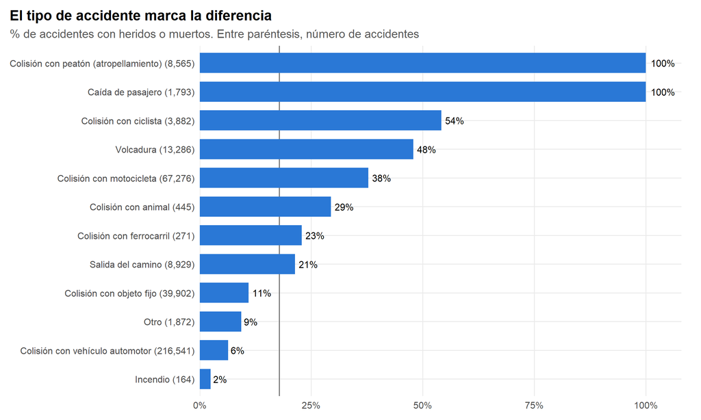

El tipo de accidente es lo que más separa a los accidentes. Los atropellamientos y las caídas de pasajero siempre tienen víctimas (100%). Los choques con ciclista (54%), las volcaduras (48%) y los choques con motocicleta (38%) están muy por encima del promedio, mientras que el choque entre vehículos, que es el más común, solo tiene víctimas en 6% de los casos.

## 2. Los conductores de 12 a 24 años tienen más accidentes con víctimas

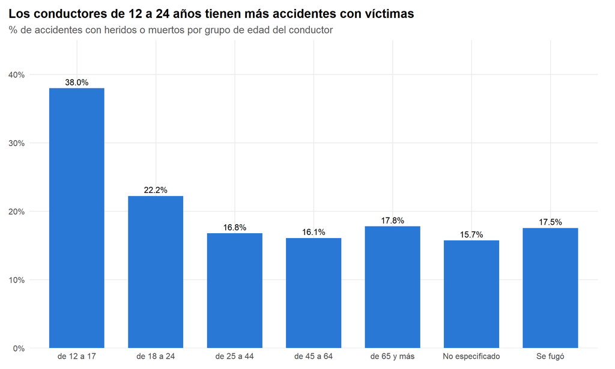

Los conductores de 12 a 17 años (38.0%) y de 18 a 24 años (22.2%) tienen más accidentes con víctimas. Con la edad en años se ve que el riesgo baja rápido hasta los 25 y después casi no cambia.

## 3. La relación con la edad no es una línea recta

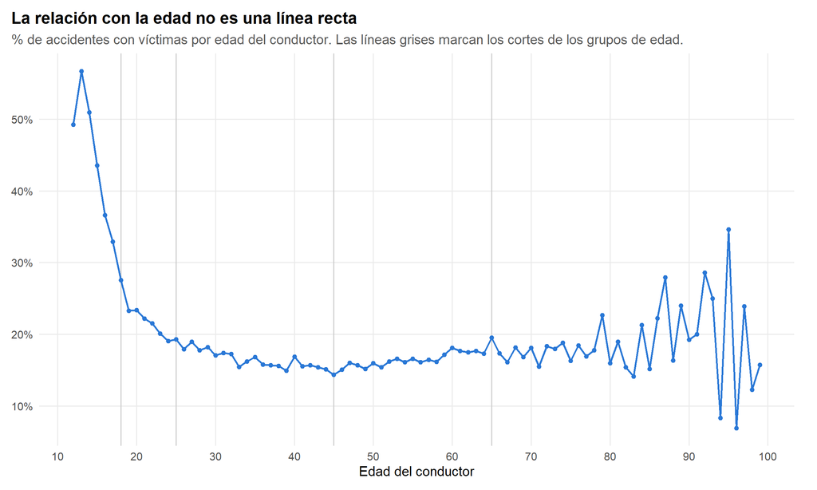

**¿Edad como variable continua o agrupada?** Con la edad vista de forma continua el riesgo baja rápido de los 12 a los 25 años y después se mantiene casi plano, con un ligero aumento después de los 65 años. Una edad continua en el modelo supondría que el efecto es el mismo por cada año (una línea recta), y además los códigos 0 (se fugó) y 99 (se ignora) no son edades. Por eso en el modelo usamos la edad agrupada.

## 4. Las noches y el domingo por la tarde concentran los accidentes más graves

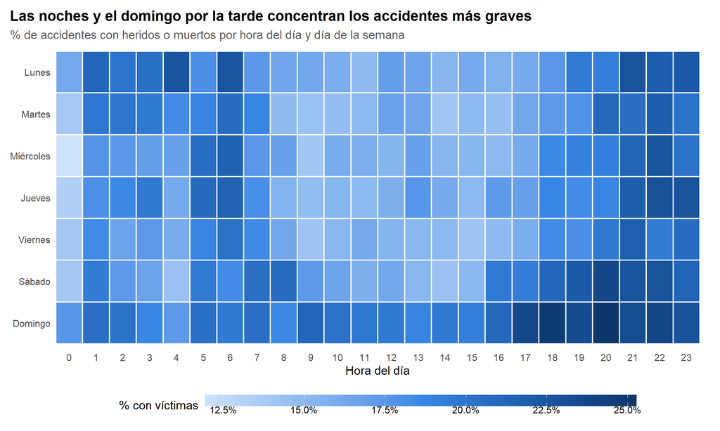

La noche, es decir de las 18 a las 23 h, y los fines de semana, sobre todo los domingos, concentran la mayor parte de los accidentes con heridos o muertos.

## 5. El lugar y momento del accidente importa

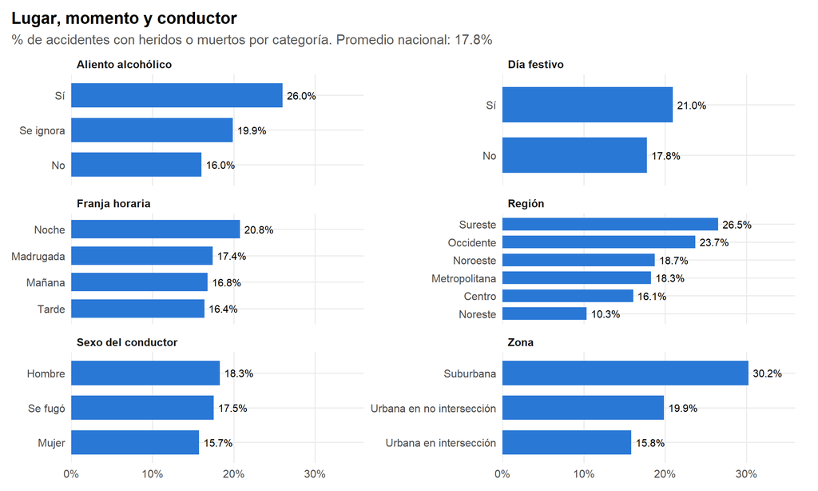

En zona suburbana el porcentaje (30.2%) casi duplica al de una intersección urbana (15.8%). Con aliento alcohólico es 26.0% contra 16.0% sin él, y en días festivos 21.0% contra 17.8%.

Por región, el Sureste (26.5%) y el Occidente (23.7%) están arriba del promedio y el Noreste (10.3%) muy abajo. En el Sureste, 35% de los accidentes son choques de motocicleta, contra 12% en el Noreste.

## 6. El Sureste y el Occidente tienen la mayor proporción de accidentes con víctimas

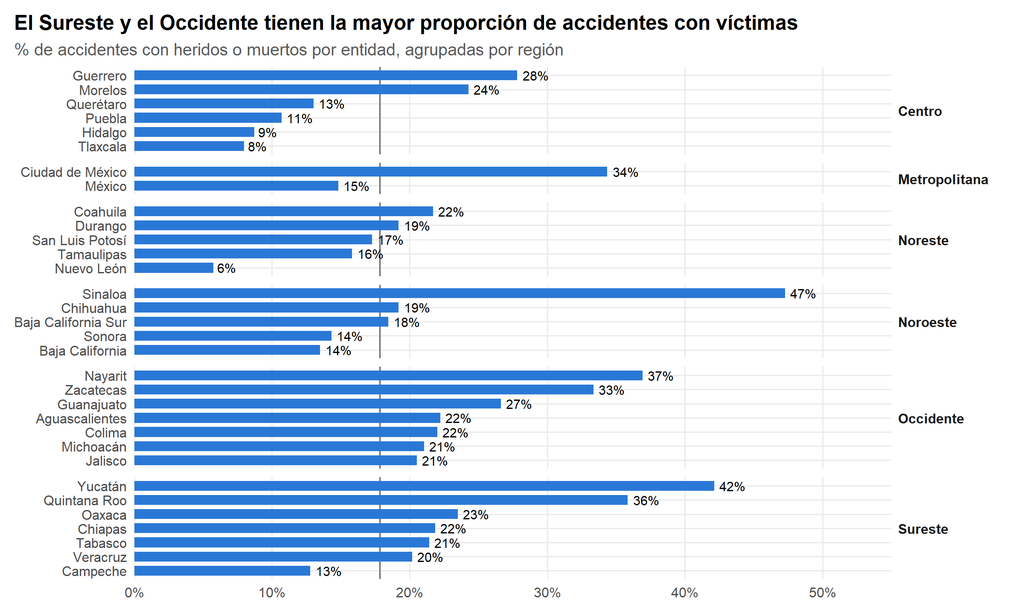

Nuevo León, la entidad con más registros, solo tiene víctimas en 6% de sus accidentes. Estas diferencias pueden reflejar también la forma en que cada entidad registra los accidentes (por ejemplo, si reporta o no los choques menores).

# Metodología

El proceso de modelado se estructuró en cuatro etapas: (1) limpieza y transformación de variables, (2) partición del conjunto de datos, (3) ajuste del modelo y (4) evaluación e interpretación de los resultados. Todo el proceso está realizado en R (`tidyverse`, `scales` y `pROC`).

En principio, la **variable objetivo** `SEVERO` se construyó a partir de `CLASACC`, asignando el valor 0 a los accidentes con sólo daños materiales y el valor 1 a los accidentes con al menos una persona herida o fallecida (clases “no fatal” y “fatal”). La variable se definió como factor con niveles ordenados (0, 1), de modo que la clase positiva corresponde a los accidentes con víctimas.

Como modelo se ajustó una **regresión logística**, que estima la probabilidad de que un accidente tenga víctimas en función de las variables explicativas.

**¿Por qué regresión logística?** Se eligió este modelo por su interpretabilidad: sus coeficientes, expresados como razones de momios (*odds ratios*), indican cuánto aumenta o disminuye la probabilidad de un accidente severo ante cada factor, manteniendo constantes los demás. Esto se alinea directamente con el objetivo de identificar los factores asociados a la severidad.

**Validación**: el conjunto de datos se dividió 70% para entrenamiento y 30% para prueba, con semilla fija `set.seed(123)` para garantizar la reproducibilidad de los resultados. El primer conjunto se utilizó para ajustar los modelos y el segundo, que no interviene en el ajuste, para evaluar su desempeño sobre datos no vistos.

**Métricas y umbral**: como solo uno de cada cinco accidentes tiene víctimas, la exactitud (accuracy) no sirve: un modelo que siempre nos dice “sólo daños” acertaría 82% de las veces sin detectar un solo accidente grave. Por eso usamos recall (métrica principal), precisión, especificidad y AUC, con un umbral de decisión de 0.2, y comparamos los resultados con otros umbrales.

**Importancia de las variables**: quitamos una variable a la vez con `drop1()` y medimos cuánto empeora el modelo con la prueba de razón de verosimilitudes.

# Modelo

## Ajuste del modelo

Ajustamos un solo modelo de regresión logística. Incluye el tipo de accidente, la región, la zona, la franja horaria, el día de la semana, si fue día festivo, el sexo del conductor, el grupo de edad del conductor y si hubo presencia de aliento alcohólico en el conductor.

- Los tipos de accidente con pocos registros (colisión con animal, ferrocarril, incendio y otro) se agrupan en “Otro”.
- Usamos como variable geográfica `REGION` y no la Entidad Federativa.
- `SEXO` y `GRUPO_EDAD` tienen la categoría “Se fugó” en exactamente los mismos registros: si el conductor huye no se sabe ni su sexo ni su edad. R detecta que son la misma columna y solo estima una: el coeficiente de “Se fugó” aparece en `SEXO` y el de `GRUPO_EDAD` sale como `NA`. No es un error.
- **Categorías de referencia**: Colisión con vehículo automotor, región Noroeste (tiene muchos registros y una tasa cercana al promedio), zona urbana en intersección, mañana, lunes, día no festivo, hombre, de 25 a 44 años y sin aliento alcohólico.

El modelo es:

$$\log\left(\frac{p_i}{1-p_i}\right) =
\beta_0 + \sum_k \beta_k x_{ik}, \qquad p_i = P(\text{SEVERO}_i = 1 \mid
x_i),$$

donde las $x_{ik}$ son indicadoras de las categorías de cada factor. Cada coeficiente se traduce en una razón de momios $e^{\beta_k}$ frente a la categoría de referencia.

Coeficientes del tipo de accidente

| Término | Beta (β) | Error Estándar | Odds Ratio (OR) |
| --- | --- | --- | --- |
| TIPOCaída de pasajero | 19.22 | 66.40 | 221775886.01 |
| TIPOColisión con ciclista | 2.88 | 0.04 | 17.81 |
| TIPOColisión con motocicleta | 2.13 | 0.01 | 8.37 |
| TIPOColisión con objeto fijo | 0.55 | 0.02 | 1.73 |
| TIPOColisión con peatón (atropellamiento) | 19.40 | 30.66 | 265388959.39 |
| TIPOOtro | 0.87 | 0.07 | 2.38 |
| TIPOSalida del camino | 1.04 | 0.04 | 2.84 |
| TIPOVolcadura | 2.36 | 0.02 | 10.64 |

El 100% de los accidentes de tipo **Atropellamientos y caídas de pasajero** tiene víctimas. El modelo intenta que su probabilidad llegue a 1 y el coeficiente se va a infinito; R se detiene en un número muy grande (alrededor de 19) con un error estándar todavía más grande. A esto se le llama **separación completa**. Por eso sus razones de momios (cientos de millones) no se pueden interpretar: lo único que nos dicen es que esos accidentes siempre tienen víctimas. Los demás coeficientes no se ven afectados.

## Evaluación del rendimiento

**Evaluación con un umbral de decisión de 0.2**

El modelo da una probabilidad para cada accidente. Para convertirla en “con víctimas” o “sólo daños” necesitamos un umbral: si la probabilidad es **0.2 o más**, el accidente se clasifica como “con víctimas”.

Usamos 0.2 porque está cerca de la proporción de accidentes con víctimas (17.7% en entrenamiento). Con 0.5 el modelo casi nunca diría “con víctimas”, porque solo uno de cada cinco accidentes las tiene.

Medimos en el conjunto de prueba:

- **Recall**: de los accidentes que **sí** tuvieron víctimas, ¿cuántos detecta el modelo? Es la métrica principal porque en seguridad vial es más grave que se escape un accidente con víctimas que dar una falsa alarma.
- **Precisión**: de los accidentes que el modelo marca con víctimas, ¿cuántos sí las tuvieron?
- **Especificidad**: de los accidentes con sólo daños, ¿cuántos identifica bien?
- **AUC**: qué tan bien separa los dos grupos sin importar el umbral (0.5 = al azar, 1 = perfecto).

No usamos la exactitud (accuracy): como solo uno de cada cinco accidentes tiene víctimas, un modelo que siempre predice “sólo daños” acertaría 82% de las veces sin detectar un solo accidente grave.

Métricas en el conjunto de prueba con el umbral de 0.2

| umbral | recall | precision | especificidad | VP | FN | FP | VN | AUC |
| --- | --- | --- | --- | --- | --- | --- | --- | --- |
| 0.2 | 71.0% | 45.8% | 81.6% | 13913 | 5681 | 16465 | 72819 | 0.829 |

**Matriz de confusión**

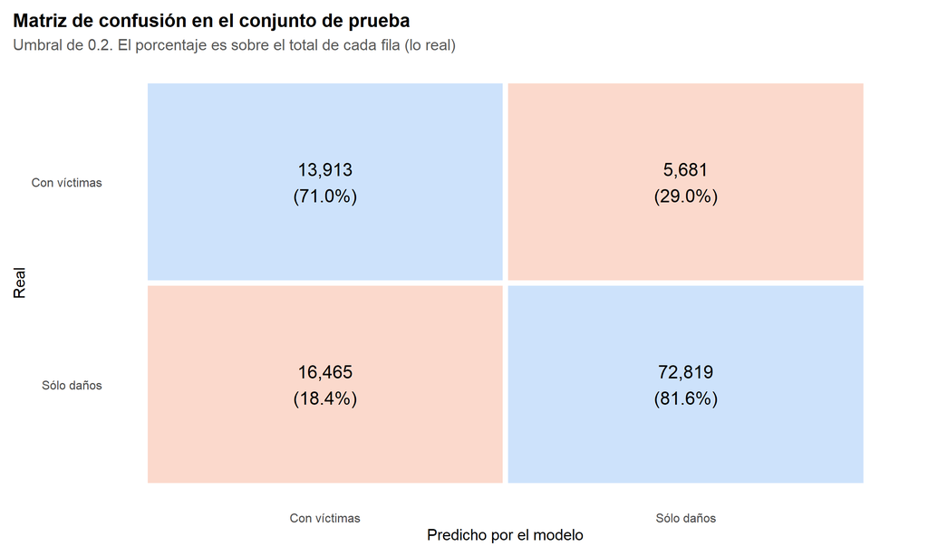

**Interpretación:**

- De los 19,594 accidentes con víctimas en el conjunto de prueba, el modelo detecta 13,913 y se le escapan 5,681.
- A cambio, 16,465 accidentes de sólo daños se marcan como “con víctimas” (falsas alarmas). Es el costo de usar un umbral bajo para priorizar el recall.

**Curva ROC**

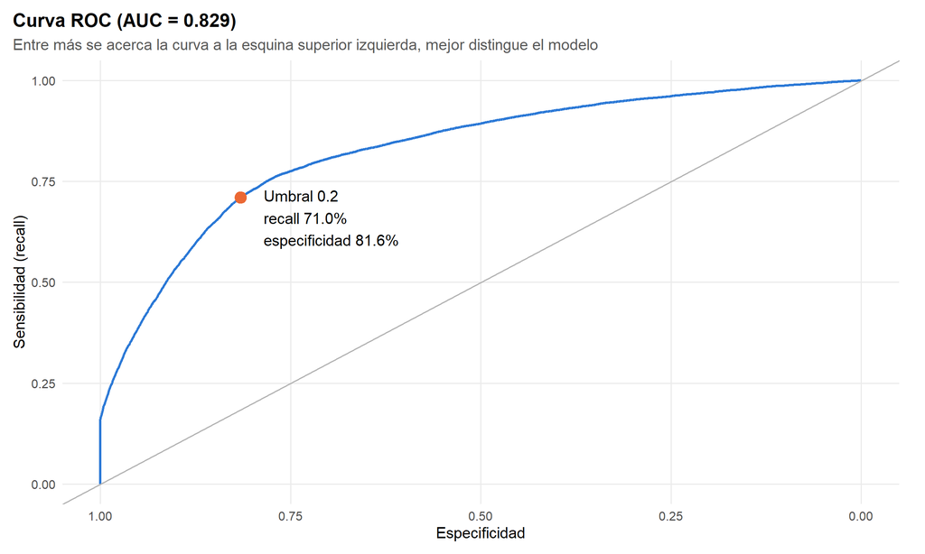

**¿Qué pasa con otros umbrales?**

Bajar el umbral detecta más accidentes con víctimas (sube el recall) a cambio de más falsas alarmas (baja la precisión). Subirlo hace lo contrario.

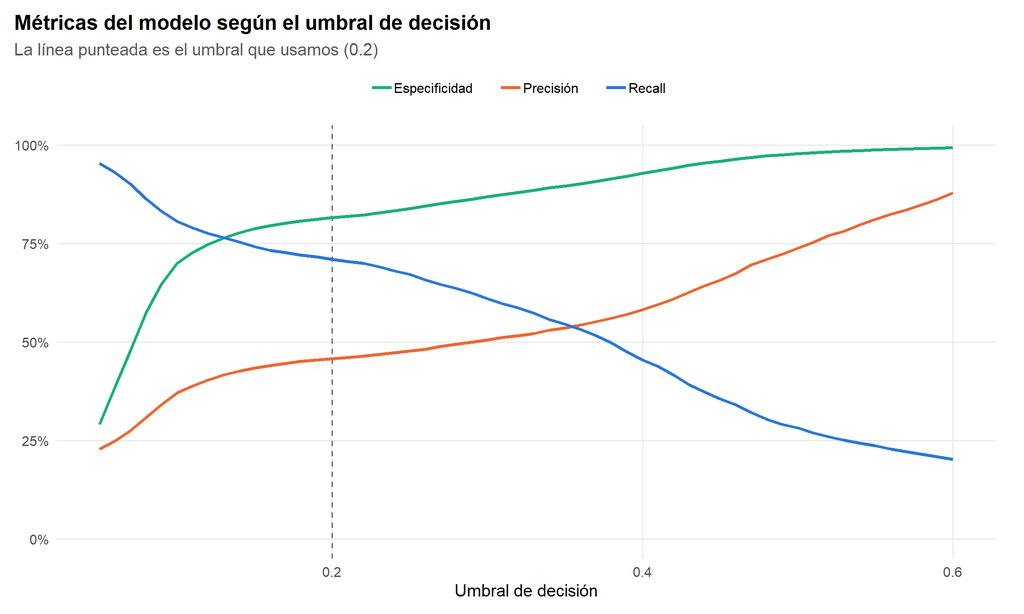

- Con un umbral de 0.2 el modelo detecta 71.0% de los accidentes con víctimas (recall). De los que marca con víctimas, 45.8% sí las tuvieron (precisión), e identifica bien 81.6% de los accidentes con sólo daños (especificidad). El AUC es de 0.829.
- Si usáramos 0.5, el recall bajaría a 28.2%: el modelo dejaría pasar casi tres de cada cuatro accidentes con víctimas.
- Parte del buen desempeño viene de los atropellamientos y las caídas de pasajero, que el modelo acierta siempre porque siempre tienen víctimas.

# Principales Resultados

## 1. ¿Qué factores se relacionan con los accidentes con víctimas?

Pasamos los coeficientes a razones de momios (OR) con `exp()`. Un OR mayor a 1 quiere decir que esa categoría tiene más probabilidad de terminar con víctimas que la categoría de referencia, dejando fijo lo demás. Los intervalos son de 95%.

Quitamos la fila de “Se fugó” en la edad porque es la que R no estimó (`NA`), y los atropellamientos y las caídas de pasajero porque su OR no se puede interpretar (separación completa).

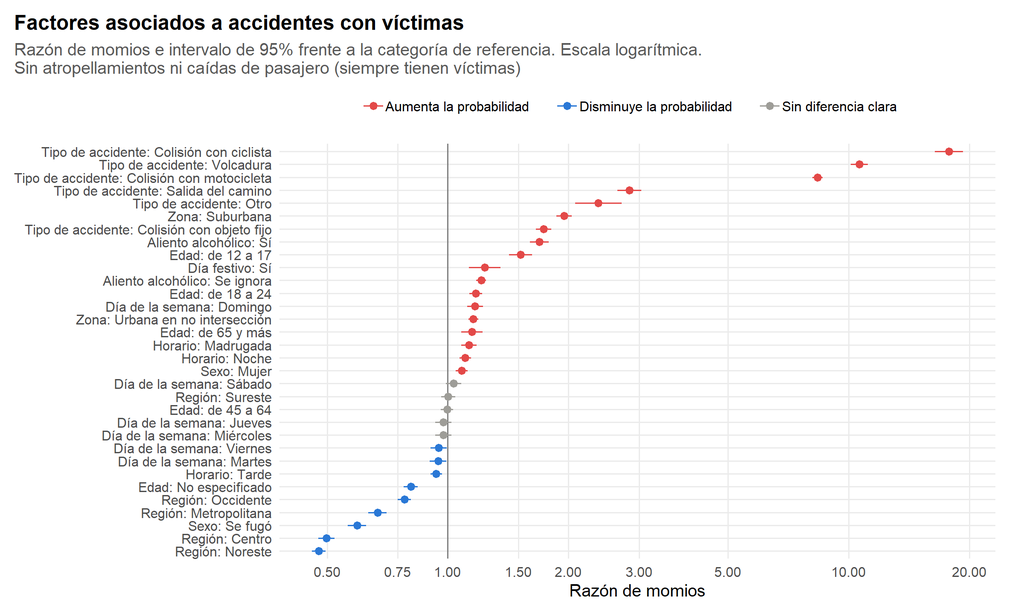

**Interpretación**:

- **Tipo de accidente**: frente a un choque entre vehículos, los momios de tener víctimas son 17.8 veces mayores en un choque con ciclista, 10.6 veces en una volcadura y 8.4 veces en un choque con motocicleta. Las salidas del camino (2.8) y los choques con objeto fijo (1.7) también aumentan el riesgo.
- **Zona**: en zona suburbana los momios casi se duplican frente a una intersección urbana (OR = 1.95).
- **Conductor**: el aliento alcohólico aumenta los momios en 69% (OR = 1.69). Los conductores de 12 a 17 años (1.52), de 18 a 24 (1.17) y de 65 o más (1.15) tienen más riesgo que los de 25 a 44. Cuando el aliento “se ignora” el riesgo también es mayor (1.21): la falta de información no es aleatoria.
- **Momento**: efectos pequeños pero significativos: madrugada (1.13), noche (1.11), domingo (1.17) y días festivos (1.24).
- **Región**: al comparar accidentes con las mismas características, el Sureste deja de destacar (OR = 1.00 frente al Noroeste): su alta proporción de accidentes con víctimas se explica sobre todo porque tiene más choques de motocicleta. El Noreste (0.48) y el Centro (0.50) sí mantienen un riesgo claramente menor, que puede reflejar tanto condiciones viales como diferencias en el registro.
- **Sexo**: en el análisis exploratorio las conductoras tienen menos accidentes con víctimas (15.7% contra 18.3%), pero al controlar por los demás factores su riesgo es ligeramente mayor (OR = 1.08). La diferencia descriptiva se debe a que tienen otro tipo de accidentes.

## 2. ¿Qué factores pesan más?

Con `drop1()` quitamos una variable a la vez y medimos cuánto empeora el modelo (prueba de razón de verosimilitudes). Entre más grande el número, más importante es la variable.

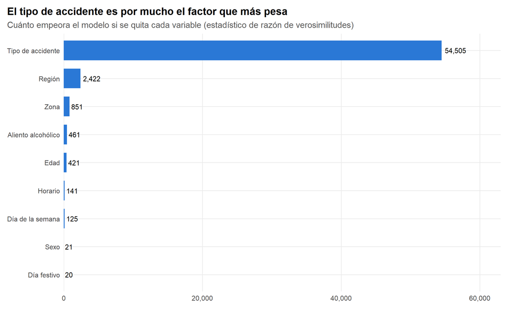

**Interpretación:** El tipo de accidente pesa por mucho más que cualquier otra variable (54,505, más de 20 veces lo que aporta la región, 2,422). Le siguen la zona (851), el aliento alcohólico (461) y la edad (421). El horario, el día de la semana, el sexo y los días festivos pesan mucho menos, aunque todas las variables son significativas.

## 3. ¿Qué aporta el modelo?

Partimos de un accidente típico en la región Noroeste y vamos agregando factores de riesgo uno por uno para ver cómo sube la probabilidad de que haya víctimas y cómo lo clasifica el modelo con el umbral de 0.2.

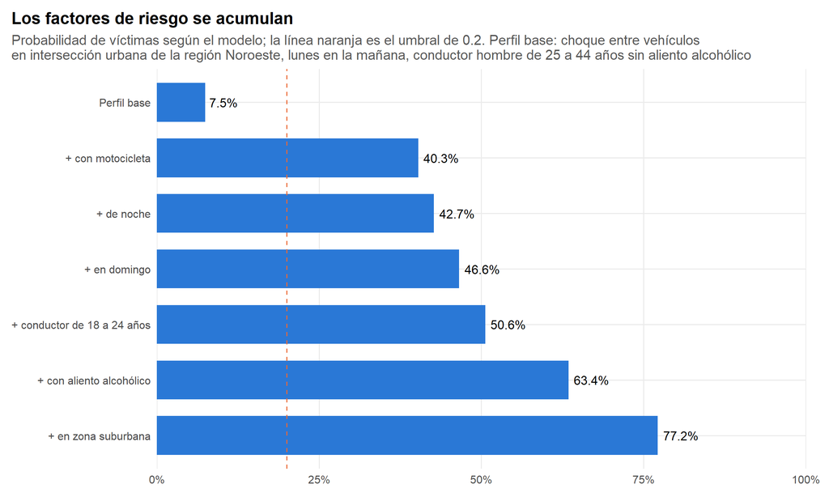

**Interpretación**:

- Con el perfil base (choque entre vehículos) la probabilidad de víctimas es de 7.5% y el modelo lo clasifica como sólo daños.
- El salto más grande lo da el tipo de accidente: con solo cambiarlo a choque con motocicleta la probabilidad sube a 40.3%, más de cinco veces.
- El aliento alcohólico (+12.8 puntos) y la zona suburbana (+13.8) son los factores que más suman después; la noche, el domingo y el conductor de 18 a 24 años agregan de 2 a 4 puntos cada uno. Combinados, llegan a 77.2%.
- Los puntos que suma cada factor dependen del orden en que se agregan, porque los efectos del modelo se multiplican en los momios.

# Conclusiones

Respondiendo a la pregunta principal, que un accidente causado por el conductor tenga víctimas depende sobre todo de **qué tipo de accidente es**: cuando hay un peatón, un ciclista o un motociclista, o cuando el vehículo vuelca, la probabilidad de heridos o muertos se multiplica. Sobre ese factor dominante, el entorno (zona suburbana) y el conductor (aliento alcohólico, edad de 12 a 24 años) suman un riesgo adicional relevante, mientras que el momento del accidente tiene efectos pequeños.

Los resultados confirman la hipótesis: todos los factores propuestos (usuarios vulnerables, volcaduras, zona suburbana, aliento alcohólico y conductores jóvenes) se asocian con una mayor probabilidad de víctimas.

Sobre las preguntas secundarias:

- El tipo de accidente pesa mucho más que las características del conductor, del lugar y del momento.
- Las diferencias entre regiones son evidentes, pero tienden a atenuarse cuando se comparan accidentes con características similares. En particular, la elevada severidad observada en el Sureste se explica principalmente por la composición de sus accidentes, donde la participación de motocicletas es más frecuente.
- Con un umbral de 0.2, el modelo detecta siete de cada diez accidentes con víctimas, con un AUC de 0.829.

# Limitaciones

- **Información faltante codificada:** Las observaciones con valores de “Se ignora”, “No especificado” y “Se fugó”, son una parte importante de los registros. Tuvimos que dejar fuera del análisis el uso del cinturón de seguridad, relevante para la severidad, por la cantidad de valores ignorados.
- **Asociación, no causalidad:** El modelo describe qué características acompañan a los accidentes con víctimas, pero no permite afirmar que un factor cause la severidad.
- **Registro administrativo heterogéneo**: Cada entidad puede registrar los accidentes de forma distinta (por ejemplo, reportar o no los choques menores), lo que afecta las comparaciones regionales. Además, la clase del accidente se registra con la información del lugar del accidente, por lo que no captura muertes posteriores.

# Posibles Extensiones

- Modelar la severidad con más detalle: Clasificación en tres clases (fatal, no fatal, sólo daños) o predecir el número de víctimas con modelos de regresión.
- Usar varios años de la ATUS para validar el modelo en el tiempo (entrenar con años anteriores y probar con el más reciente) y analizar tendencias.
- Incorporar datos de exposición, como el parque vehicular por entidad (Vehículos de Motor Registrados en Circulación, INEGI), para calcular tasas de accidentes graves por vehículo, y usar la versión georreferenciada de la ATUS para análisis espacial.